# Project : Genetic Mutation Prediction

### 4.2 Length of Clinical Evidence Text

We found that number of characters in a document varies from 3 to a maximum of ~0.4 million with mean ~50,000. We assume some of the documents with very little text should be excluded from the prediction as they may not have enough information for prediction.

```python
df['Length of text']=df['Edited_Text'].str.len()
df['Length of text'].describe()
```

```
count      3689.000000
mean      50784.216048
std       42074.514229
min           3.000000
25%       24886.000000
50%       36895.000000
75%       63469.000000
max      421342.000000
Name: Length of text, dtype: float64
```

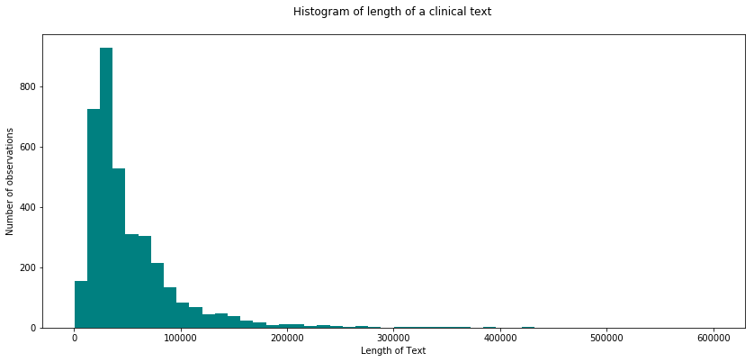

```python
#Histogram of the length of text
plt.figure(figsize=(14,6))
plt.hist(df['Length of text'],bins=50,range=(300,600000),color='teal')
plt.xlabel('Length of Text')
plt.ylabel('Number of observations')
plt.title('Histogram of length of a clinical text \n')
plt.show()
```

### 4.3 Frequency of Mutation Types

We want to see if there is any pattern by genetic mutation class. Through the histogram, we can see that class 7 is the most dominant class followed by class 4 and 1, while some of the smaller mutation types are under-represented. Representation of class is especially low compared to other mutation classes. We expect this skewness could also impact prediction especially for categories that are under-represented.

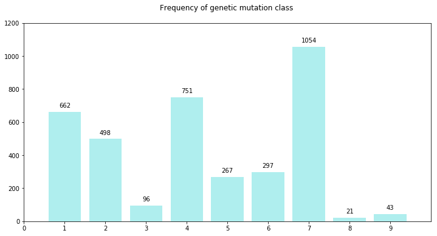

```python
mutation_df=df.groupby(['Class'])[['ID']].count()
mutation_df.columns=['Count']
#Barchart of number of observations of each mutation type
plt.figure(figsize=(12,6))
plt.bar(x=mutation_df.index,height=mutation_df['Count'],color='paleturquoise')
for i in range(0,len(mutation_df)):
    plt.text(x=(i+1),y=mutation_df.iloc[i,0]+20,s=str(mutation_df.iloc[i,0]),ha='center', va='bottom')
plt.xlim([0,10])
plt.ylim([0,1200])
plt.xticks(np.arange(0,10,1))
plt.title('Frequency of genetic mutation class \n')
plt.show()
```